- Group Information
- Peak Calling Statistics
- Annotation of Peaks

# Azenta ChIP-seq Group Report

## 1. Group Information

| Customer | Anders Ohman |
| --- | --- |
| Email | anders_ohman@brown.edu |
| QuoteNumber | 30-748712749 |
| Configuration |  |
| Group | Fetal-2m1 |

## 2. Peak Calling Statistics

MACS2 2.1.2 was used to call peaks for each sample in group Fetal-2m1. Called peaks were merged within each group and peaks called in at least 4 samples were kept for downstream analysis.

| Sample | Number of Peaks |
| --- | --- |
| D1-2m1 | 62 |
| D2-2m1 | 18166 |
| L1-2m1 | 6747 |
| L2-2m1 | 326 |
| S1-2m1 | 2874 |
| S2-2m1 | 49728 |
| Merged | 475 |

## 3. Peak Annotation

### 3.1 Average ChIP-seq profile at annotated transcription start site (TSS) regions.

Figure 3.1 shows the average profile of ChIP-seq peaks falling within +/- 3Kb of annotated TSS sites genome-wide.  
This profile indicates whether called peaks are enriched around promoters.

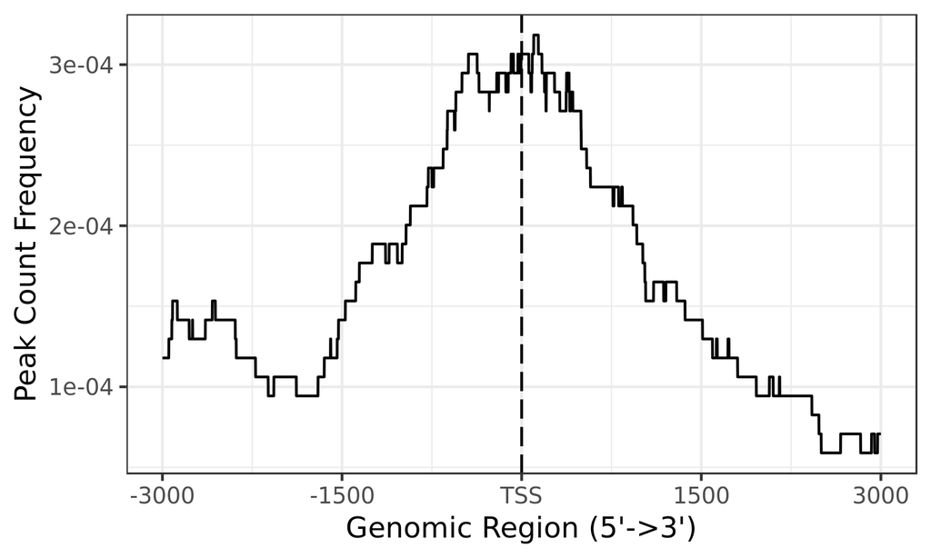

Figure 3.1 Average ChIP-seq peak profile within +/- 3Kb of annotated TSS’s

### 3.2 Peak annotation by genomic feature

Peaks were annotated based on the genomic features they overlap. When annotations overlap assignment priorities are: Promoter > 5’UTR > 3’UTR > Exon > Intron > Downstream > Intergenic.

Figure 3.2 Composition of peak overlaps with annotated genomic features

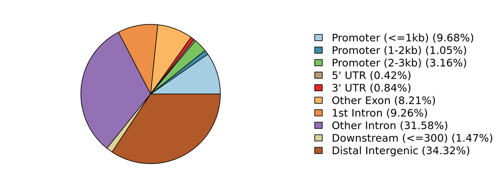

Figure 3.2 Composition of annotated peaks

Figure 3.3 Histogram of overlapping features under merged peaks, ranked by the number of peaks.

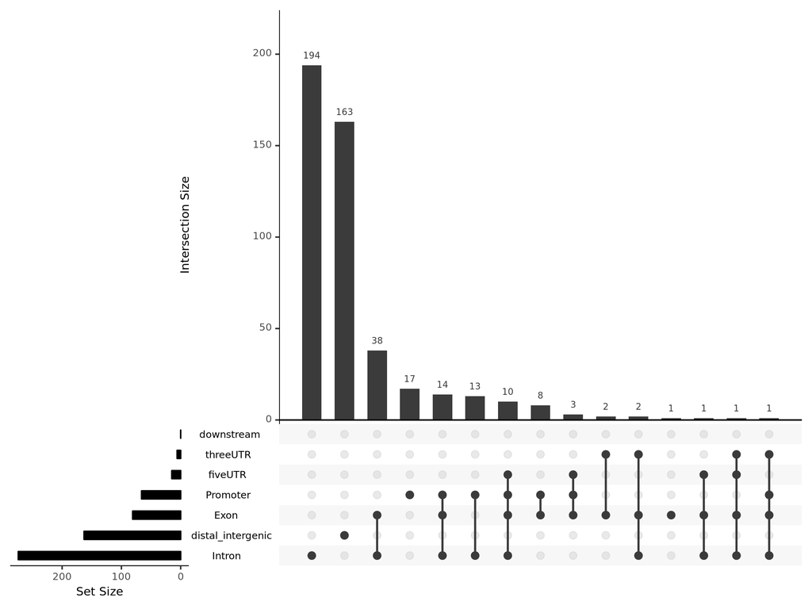

Figure 3.3 Overlapping genomic features by peak count

Figure 3.4 Distribution of genomic distances from peak summits to the nearest TSS.

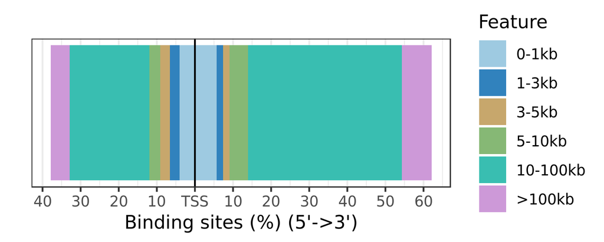

Figure 3.4 Distribution of genomic distance from peak summits to the nearest TSS

Table 3.1 First 100 peaks from the annotated peaks table.

| chr | start | end | strand | annotation | geneStart | geneEnd | geneStrand | geneId | transcriptId | distanceToTSS | gene_symbol | gene_name | gene_biotype | description |
| --- | --- | --- | --- | --- | --- | --- | --- | --- | --- | --- | --- | --- | --- | --- |
| 1 | 19274497 | 19275641 | * | Intron (ENSRNOT00000015547/ENSRNOG00000011245, intron 7 of 14) | 19227121 | 19376301 | 2 | ENSRNOG00000011245 | ENSRNOT00000015547 | 100660 | Arhgap18 | Arhgap18 | protein_coding | Rho GTPase activating protein 18 [Source:RGD Symbol;Acc:1305053] |
| 1 | 29023915 | 29025568 | * | Distal Intergenic | 29191192 | 29201531 | 1 | ENSRNOG00000013364 | ENSRNOT00000018718 | -165624 | Hey2 | Hey2 | protein_coding | hes-related family bHLH transcription factor with YRPW motif 2 [Source:RGD Symbol;Acc:621405] |
| 1 | 29238525 | 29240576 | * | Intron (ENSRNOT00000018849/ENSRNOG00000014004, intron 1 of 16) | 29225707 | 29385199 | 1 | ENSRNOG00000014004 | ENSRNOT00000018849 | 12818 | Ncoa7 | Ncoa7 | protein_coding | nuclear receptor coactivator 7 [Source:RGD Symbol;Acc:1566426] |
| 1 | 29533217 | 29534878 | * | Distal Intergenic | 29432174 | 29487317 | 1 | ENSRNOG00000014240 | ENSRNOT00000083276 | 101043 | Trmt11 | Trmt11 | protein_coding | tRNA methyltransferase 11 homolog [Source:RGD Symbol;Acc:727798] |
| 1 | 38402368 | 38405089 | * | Distal Intergenic | 38428386 | 38428472 | 2 | ENSRNOG00000054816 | ENSRNOT00000078859 | 23383 |  | AABR07001151.1 | misc_RNA |  |
| 1 | 38414477 | 38417638 | * | Distal Intergenic | 38428386 | 38428472 | 2 | ENSRNOG00000054816 | ENSRNOT00000078859 | 10834 |  | AABR07001151.1 | misc_RNA |  |
| 1 | 38425971 | 38428371 | * | Promoter (&lt;=1kb) | 38428386 | 38428472 | 2 | ENSRNOG00000054816 | ENSRNOT00000078859 | 101 |  | AABR07001151.1 | misc_RNA |  |
| 1 | 38991745 | 38992608 | * | Intron (ENSRNOT00000087610/ENSRNOG00000053328, intron 4 of 4) | 38895131 | 39035633 | 2 | ENSRNOG00000053328 | ENSRNOT00000087610 | 43025 |  | AABR07001233.1 | lincRNA |  |
| 1 | 39245915 | 39247191 | * | Distal Intergenic | 38895131 | 39035633 | 2 | ENSRNOG00000053328 | ENSRNOT00000087610 | -210282 |  | AABR07001233.1 | lincRNA |  |
| 1 | 39258415 | 39259675 | * | Distal Intergenic | 38895131 | 39035633 | 2 | ENSRNOG00000053328 | ENSRNOT00000087610 | -222782 |  | AABR07001233.1 | lincRNA |  |

[output cut: 90 more lines]

- Azenta Life Sciences
- Next Generation Sequencing
- Email: ngs@azenta.com
- Phone: 908-222-0711 ext 1